# hw7

# 6.10. Refer to Grocery retailer Problem 6.9.

## a. Fit regression model (6.5) to the data for three predictor variables. State the estimated regression function. How are b l , b2 , and b 3 interpreted here?

```r
#model is y=b0+b1*x1+b2*x2+b3*x3
model=lm(y~x1+x2+x3,data=grocerry)
summary(model)
```

```
##
## Call:
## lm(formula = y ~ x1 + x2 + x3, data = grocerry)
##
## Residuals:
##     Min      1Q  Median      3Q     Max
## -264.05 -110.73  -22.52   79.29  295.75
##
## Coefficients:
##               Estimate Std. Error t value Pr(>|t|)
## (Intercept)  4.150e+03  1.956e+02  21.220  < 2e-16 ***
## x1           7.871e-04  3.646e-04   2.159   0.0359 *
## x2          -1.317e+01  2.309e+01  -0.570   0.5712
## x3           6.236e+02  6.264e+01   9.954 2.94e-13 ***
## ---
## Signif. codes:  0 '***' 0.001 '**' 0.01 '*' 0.05 '.' 0.1 ' ' 1
##
## Residual standard error: 143.3 on 48 degrees of freedom
## Multiple R-squared:  0.6883, Adjusted R-squared:  0.6689
## F-statistic: 35.34 on 3 and 48 DF,  p-value: 3.316e-12
```

```r
# How are b l , b2 , and b 3 interpreted here?
## when x2 and x3 are kept constant, for a given x1 y changes by b1
## when x1 and x3 are kept constant, for a given x2 y changes by b2
## when x1 and x2 are kept constant, for a given x3 y changes by b3
```

## b. Obtain the residuals and prepare a,box plot of the residuals. What information does this plot provide?

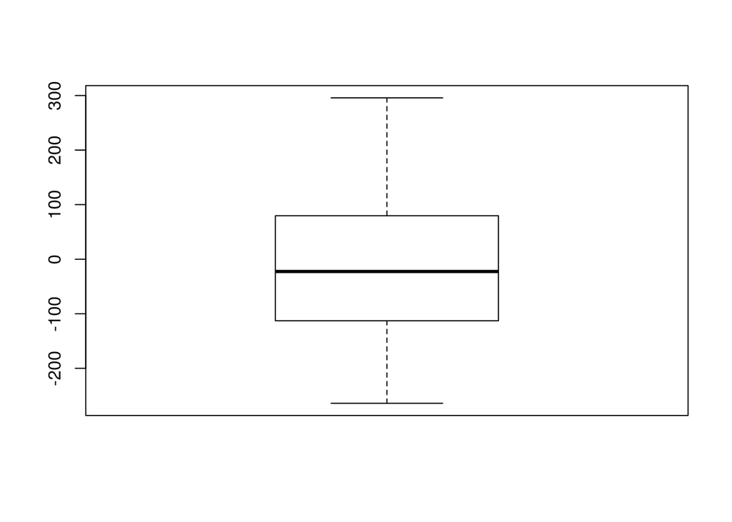

```r
residuals_model=resid(model)
boxplot(residuals_model)
```

```r
# What information does this plot provide?
## there are no outliers in residuals
### indicate that e has a acceptable variance which is near constant
### mean is 0 and the upper tail and lower tail of the box plot is symmetric which indicate that residuals are close to normality with constant variance
```

## c. Plot the residuals against Y, X I, X 2 , X 3 , and X I X2 on separate graphs. Also prepare a normal probability plot. Interpret the plots and su~arize your findings.

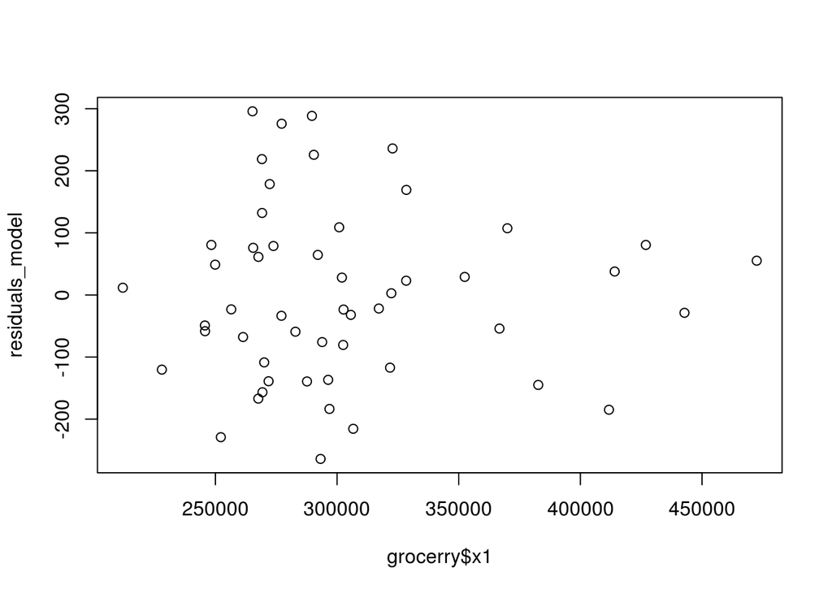

```r
plot(grocerry$x1,residuals_model)
```

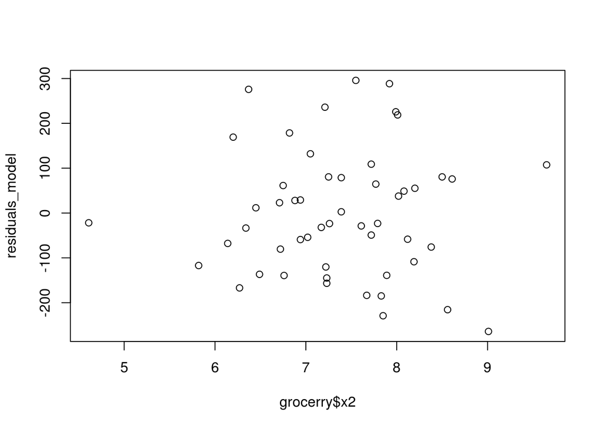

```r
# Presence of outliers -residuals at points 300 and less than -200
# Constant variance is not visisble as the terms have more variance at 25000 - 30000 range
# non linearity of regression model ~ clustering of data around 25,000 -30000 range

plot(grocerry$x2,residuals_model)
```

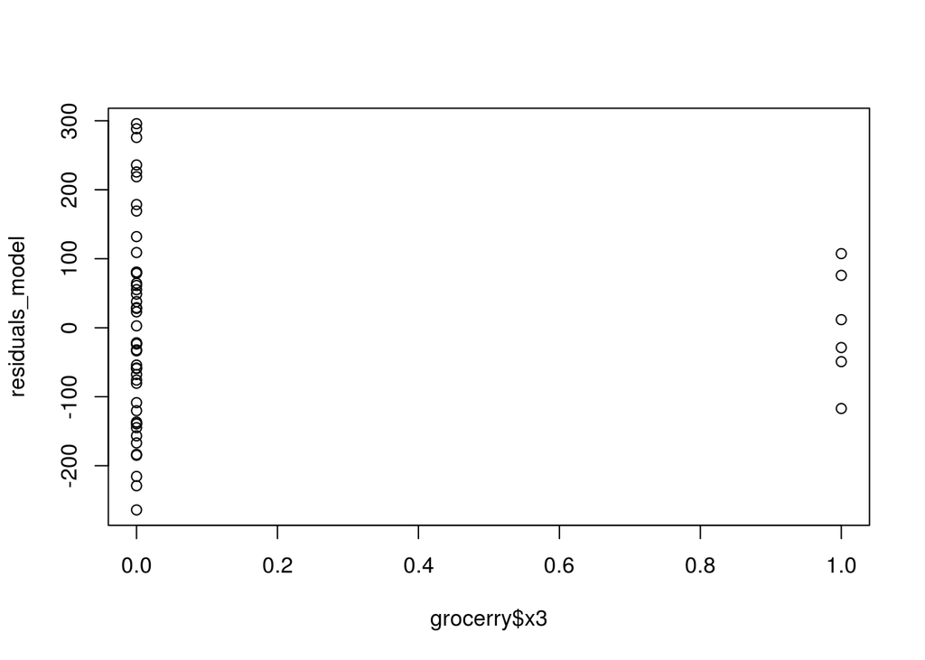

```r
# presence of outliers ~ residuals at extremes
# clustering of data indicating that linear model may not be the best fit

plot(grocerry$x3,residuals_model)
```

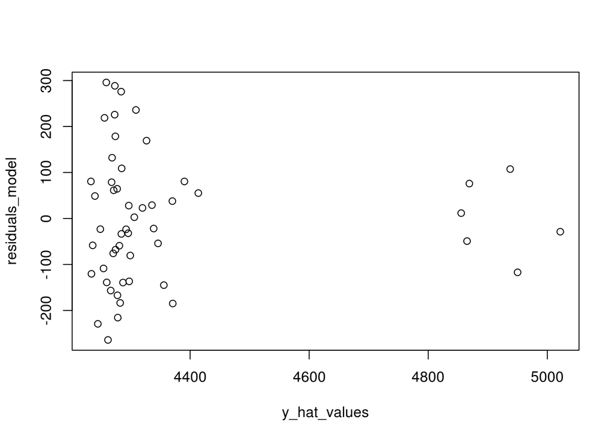

```r
#difficult to infer anything from such a plot
# Categorical variable would result in such a plot

y_hat_values=fitted(model)
plot(y_hat_values,residuals_model)
```

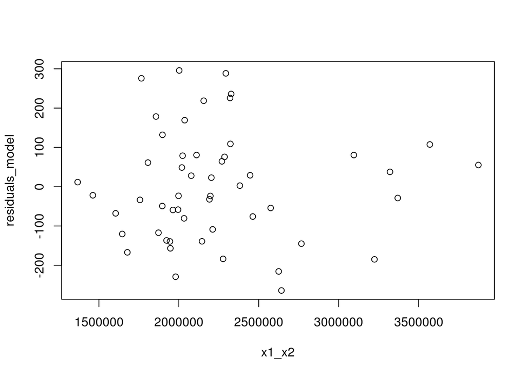

```r
# the speread of the data indicates that the observations have a good range thus reducing our standard error, thus increasing  our prediction and confidence intervals

x1_x2=c(grocerry$x1*grocerry$x2)
plot(x1_x2,residuals_model)
```

```r
## This indicate normal distribution,x1 and x2 is not in the model thus we cannot conclude anything
```

[output not shown]

## d. Prepare a time plot of the residuals. Is there any indication.o1:hat the error terms are correlated?

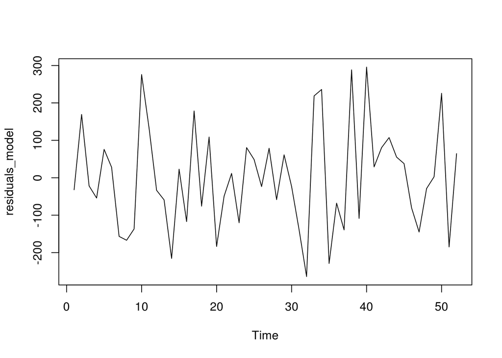

```r
plot.ts(residuals_model)
```

```r
## There is no linear relation in the plot,indicating that error terms are not increasing or decreasing by time, thus not correalted.There also seems to be no cyclic or seasonal relation
```

# 6.11

## a. Test whether there is a regression relation, using level of significance .05. State the alternatives, decision nJle, and conclusion. What does yom’ test result imply about fJl’ f32, and fJ3? What is the P-value of the test

```r
summary(model)
```

```
##
## Call:
## lm(formula = y ~ x1 + x2 + x3, data = grocerry)
##
## Residuals:
##     Min      1Q  Median      3Q     Max
## -264.05 -110.73  -22.52   79.29  295.75
##
## Coefficients:
##               Estimate Std. Error t value Pr(>|t|)
## (Intercept)  4.150e+03  1.956e+02  21.220  < 2e-16 ***
## x1           7.871e-04  3.646e-04   2.159   0.0359 *
## x2          -1.317e+01  2.309e+01  -0.570   0.5712
## x3           6.236e+02  6.264e+01   9.954 2.94e-13 ***
## ---
## Signif. codes:  0 '***' 0.001 '**' 0.01 '*' 0.05 '.' 0.1 ' ' 1
##
## Residual standard error: 143.3 on 48 degrees of freedom
## Multiple R-squared:  0.6883, Adjusted R-squared:  0.6689
## F-statistic: 35.34 on 3 and 48 DF,  p-value: 3.316e-12
```

```r
nrow(grocerry)
```

```
## [1] 52
```

```r
qt(df=52-4,0.95)
```

```
## [1] 1.677224
```

## c. Calculate the coefficient of multiple determination R’l. How is this measm-e interpl-eted hel-e?

### Multiple R-squared: 0.6883, Adjusted R-squared: 0.6689

### indicate the amount of variation of Y explained by the predictor variables to the total variation in Y(Ratio)

# 6.12

## Obtain the family of estimates using a 95 percent family confidence coefficient. Employ the Working-Hotelling 01’ the Bonfemmi p1“ocedure, whichevel’ is mOl-e efficient.

### g=5 1-alpha/2g = 0.995

### p=4 n-p=48

### if we use bonferroni our ci will be calculated using t(0.995,48) 2.68

### if we use working-hotelling w=sqrt(g*F(1-alpha,g,n-p)) = sqrt(qf(0.95,df1=5,df2=48)*5) =3.470241

### so bonferroni is better because it gives us tighter interval

### s^2{predmean} = (x_h)T * s^2{B} * (x_h)

```r
xmatrix=cbind(1,grocerry$x1,grocerry$x2,grocerry$x3)
mse=20532
s2b=solve(t(xmatrix)%*%xmatrix)*mse

calculate_bonferroni_interval=function(s2b,bon_t_value,x_value1){

x_value=matrix(c(1,x_value1))

x_value1=data.frame(t(x_value1))
setnames(x_value1,c("x1","x2","x3"))
y_pred=predict.lm(model,x_value1)

s2_y_hat=t(x_value)%*%s2b%*%x_value
s2_y=sqrt(s2_y_hat)
cat(y_pred-((bon_t_value)*s2_y),"<= E{Y} <=",y_pred+((bon_t_value)*s2_y))
}
calculate_bonferroni_interval(s2b,2.68,c(302000,7.2,0))
```

```
## 4235.554 <= E{Y} <= 4350.026
```

```r
calculate_bonferroni_interval(s2b,2.68,c(245000,7.4,0))
```

```
## 4165.692 <= E{Y} <= 4324.895
```

```r
calculate_bonferroni_interval(s2b,2.68,c(280000,6.9,0))
```

```
## 4213.913 <= E{Y} <= 4344.935
```

```r
calculate_bonferroni_interval(s2b,2.68,c(350000,7.0,0))
```

```
## 4255.672 <= E{Y} <= 4410.734
```

```r
calculate_bonferroni_interval(s2b,2.68,c(295000,6.7,1))
```

```
## 4749.918 <= E{Y} <= 5084.918
```

## b. FOI’ the data in Problem 6.9 on which the regression fit is based, would you consider a shipment of 400,000 cases with an indirect percentage of 7.20 on a nonholiday week to be within the scope of the model? What about a shipment of 400,000 cases with an indil-ect percentage of9.9 on a nonholiday week? Support your answers by p1“eparing a l-elevant plot.

### for the first one – YES

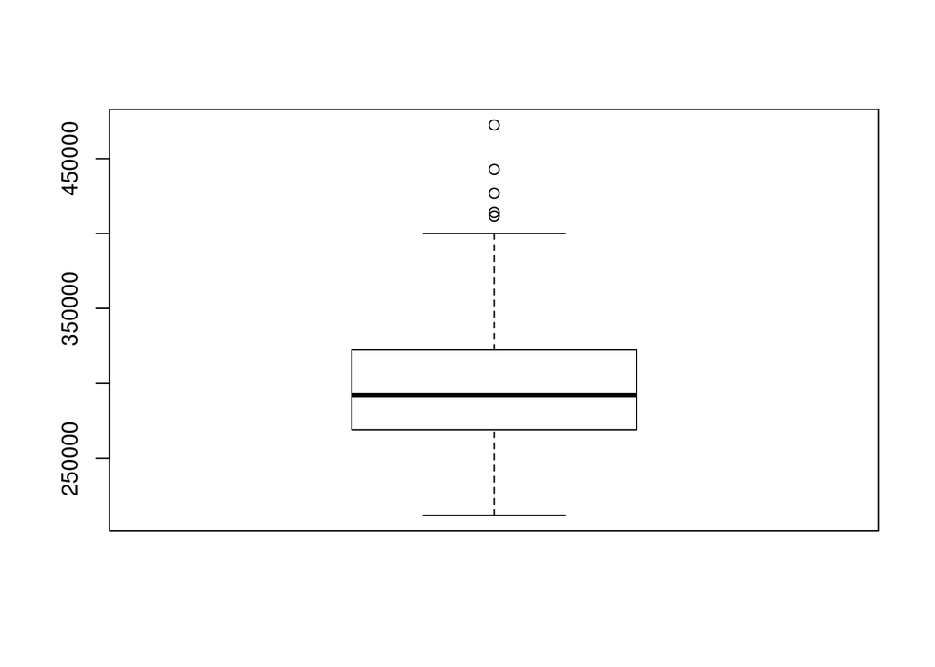

```r
boxplot(c(grocerry$x1,400000))
```

```r
## clearly 400000 is not an outlier, it is in within the upper range
```

### for the second one – NO

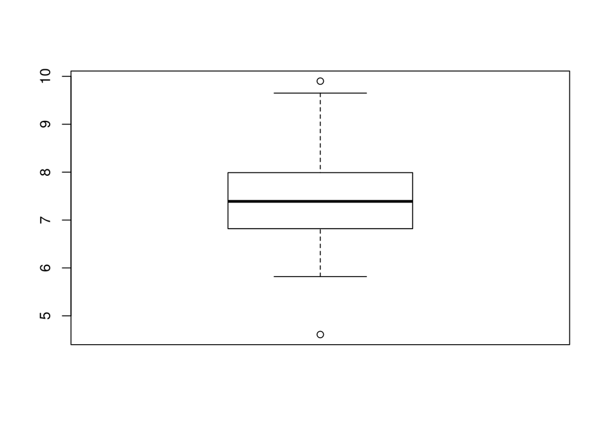

```r
boxplot(c(grocerry$x2,9.9))
```

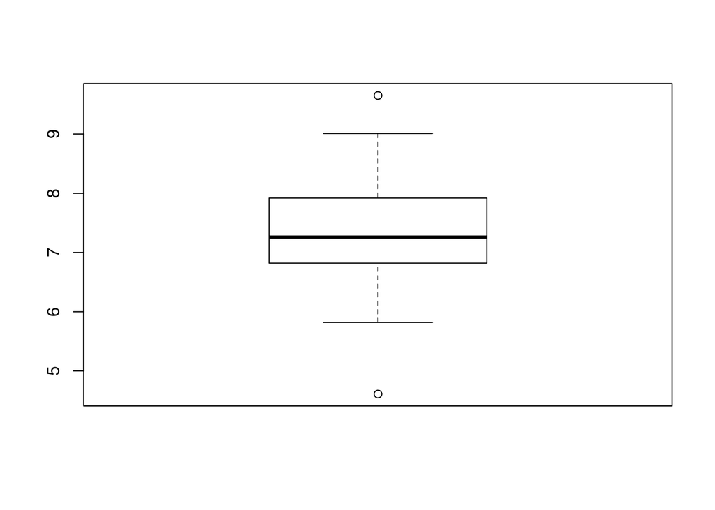

```r
## 9.9 is an outlier
boxplot(c(grocerry$x2,7.20))
```

```r
## 7.2 is not
```

# 6.13

## Management desires p1-edictions of the handling times for these shipments so that the actual handling times can be compared with the pl-edicted times to determine whether any are out of line. Develop the needed predictions, using the most efficient approach and a family confidence coefficient of 95 percent.

## Obtain the family of estimates using a 95 percent family confidence coefficient. Employ the Working-Hotelling 01’ the Bonfemmi p1“ocedure, whichevel’ is mOl-e efficient.

### g=4 1-alpha/2g = 0.99375

### p=4 n-p=48

### if we use bonferroni our ci will be calculated using t(0.99375,48) 2.59

### if we use working-hotelling w=sqrt(g*F(1-alpha,g,n-p)) = sqrt(qf(0.95,df1=4,df2=48)*4) =3.203274

### so bonferroni is better because it gives us tighter interval

### s^2{predmean} = (x_h)T * s^2{B} * (x_h)

```r
mse=20532
s2b=solve(t(xmatrix)%*%xmatrix)*mse

calculate_bonferroni_interval_mse=function(s2b,bon_t_value,x_value1,mse){

x_value=matrix(c(1,x_value1))

x_value1=data.frame(t(x_value1))
setnames(x_value1,c("x1","x2","x3"))
y_pred=predict.lm(model,x_value1)

s2_y_hat=(t(x_value)%*%s2b%*%x_value)+mse
s2_y=sqrt(s2_y_hat)
cat(y_pred-((bon_t_value)*s2_y),"<= Y_h <=",y_pred+((bon_t_value)*s2_y))
}
calculate_bonferroni_interval_mse(s2b,2.59,c(230000,7.5,0),mse)
```

```
## 3850.694 <= Y_h <= 4613.647
```

```r
calculate_bonferroni_interval_mse(s2b,2.59,c(250000,7.3,0),mse)
```

```
## 3872.254 <= Y_h <= 4628.836
```

```r
calculate_bonferroni_interval_mse(s2b,2.59,c(280000,7.1,0),mse)
```

```
## 3900.893 <= Y_h <= 4652.689
```

```r
calculate_bonferroni_interval_mse(s2b,2.59,c(340000,6.9,0),mse)
```

```
## 3948.689 <= Y_h <= 4704.609
```

# 6.14

## a. Obtain a 95 percent pl-ediction interval fOl’ the mean handling time fOl’ these shipments.

```r
x_value=matrix(c(282000,7.1,0))
x_value1=data.frame(t(x_value))
x_value=matrix(c(1,282000,7.1,0))
setnames(x_value1,c("x1","x2","x3"))
y_pred=predict.lm(model,x_value1)

s2_y_hat=(t(x_value)%*%s2b%*%x_value)+(mse/3)
s2_y=sqrt(s2_y_hat)
print(s2_y)
```

```
##          [,1]
## [1,] 85.82283
```

```r
t_value=qt(0.975,48)
print(t_value)
```

```
## [1] 2.010635
```

```r
cat(y_pred-((t_value)*s2_y),"<= Y_H <=",y_pred+((t_value)*s2_y))
```

```
## 4105.807 <= Y_H <= 4450.924
```

## b. Convert the inteJ:val obtained in part (a) into a 95 percent prediction interval for the total labol’ hours for the three shipments.

```r
cat((y_pred-((t_value)*s2_y))*3,"<= Y_H*3 <=",(y_pred+((t_value)*s2_y))*3)
```

```
## 12317.42 <= Y_H*3 <= 13352.77
```